# ADA (week 8) Introduction to Stan: Self-practice & homework exercises

Florian Pätzold, 977687

06/09/2020

# Instructions

- Use the file `08-exercises.Rmd`, solve the exercises marked as homework, and save the file with your student number and name.
- ‘Knit’ the document to produce a HTML file.
  - **include the other JS and CSS files that came with the ZIP file for this week in order to produce nicely looking Stan code in the HTML**
- **include the Stan code you write in the Rmarkdow (see example in exercise 1 below), even if you also include a seperate file to run that model from**
- Please do not suppress the code in the HTML-Output!
  - **do suppress the output of Stan by including the flag `results = "hide"` in the r chunk calling the `stan` function (see example in self-practice exercise 1)**
- Create a ZIP archive called “MATRIKELNR_Lastname_Firstname_ABDA_Week4.zip” containing:
  - an R Markdown file “MATRIKELNR_Lastname_Firstname_ABDA_Week4.Rmd”
  - a knitted HTML document “MATRIKELNR_Lastname_Firstname_ABDA_Week4.html”
  - **all of your Stan code files**
  - **the auxilliary JS and CSS files for syntax highlighting of Stan code**
- Upload the ZIP archive on Stud.IP in the homework folder before the deadline. You may upload as many times as you like before the deadline, only your final submission will count.

# Preliminaries

We need the package `rstan` installed and loaded for this week’s exercises.

We are going to set a seed, so that results from (pseudo-)random executions are repeatable.

```r
set.seed(1969)
```

# Motivation and learning goals

The main **learning goals** of this week’s practical part are:

- become familiar with Stan
- see a simple and some increasingly more difficult models implemented in Stan
- become comfortable with minor manipulations to Stan programs
- understand robust (regression) modeling

# Exercise 1 [SELF-PRACTICE]: Inferring a single Gaussian: priors & posterior predicitives

We are going to, yet again (!), estimate the joint posterior of the mean $\mu$ and standard deviation $\sigma$ that could have generated the following fictitious (flower) data:

```r
# flower height data (as before)
heights_A <- c(6.94, 11.77, 8.97, 12.2, 8.48,
               9.29, 13.03, 13.58, 7.63, 11.47,
               10.24, 8.99, 8.29, 10.01, 9.47,
               9.92, 6.83, 11.6, 10.29, 10.7,
               11, 8.68, 11.71, 10.09, 9.7)
# store the data in a vector with a better name & record its length
y <- heights_A
N <- length(y)
```

## 1.a Minimal model with improper priors

In a first minimal model, we assume improper priors on $\mu$ and $\sigma$, assuming that every pair of values for these parameters is equally likely *a priori*, except that $\sigma$ ought to be positive. The Stan code for this model is:

```stan
data {
  int<lower=1> N ;
  vector[N] y ;
}
parameters {
  real mu ;
  real<lower=0> sigma ;
}
model {
  y ~ normal(mu, sigma) ;
}
```

Notice that improper priors are used here, because we didn’t specify any prior on $\mu$ or $\sigma$. We only declared that $\sigma$ has a lower bound at 0.

We prepare the data to be fed into Stan:

```r
# prepare the data for Stan
dataList = list(y = y, N = N)
```

```r
# fit the model to the data
fit_1a = stan(
  file = 'ADA-W08-Ex1a-single-Gaussian.stan',
  data = dataList
)
```

We can inspect a summary of the `stanfit` object in variable `fit_1a`:

```r
fit_1a
```

```
## Inference for Stan model: ADA-W08-Ex1a-single-Gaussian.
## 4 chains, each with iter=2000; warmup=1000; thin=1;
## post-warmup draws per chain=1000, total post-warmup draws=4000.
##
##         mean se_mean   sd   2.5%    25%    50%    75%  97.5% n_eff Rhat
## mu     10.04    0.01 0.38   9.29   9.79  10.05  10.30  10.77  2541    1
## sigma   1.86    0.01 0.29   1.39   1.66   1.82   2.02   2.53  2151    1
## lp__  -27.21    0.03 1.09 -30.04 -27.64 -26.87 -26.42 -26.13  1284    1
##
## Samples were drawn using NUTS(diag_e) at Wed Jun 10 14:15:09 2020.
## For each parameter, n_eff is a crude measure of effective sample size,
## and Rhat is the potential scale reduction factor on split chains (at
## convergence, Rhat=1).
```

We can interpret the information about the quantiles, means, R-hat and number of efficient samples, as before (in the context of using the `brms` package).

## 1.b Adding prior information and obtaining samples from the posterior predictive distribution

We are going to add wide relatively uninformative priors, just to see how this looks like. We do not expect this to change the posterior inference (much). In particular, we are going to set the prior of $\mu$ to a normal distribution with mean 0 and standard deviation 100. We are going to use a [truncated cauchy distribution](http://bois.caltech.edu/distribution_explorer/continuous/halfcauchy.html#:~:text=In%20Stan%2C%20a%20Half%2DCauchy,of%20the%20Half%2DCauchy%20distribution) for the prior on $\sigma$ with mean/mode 0, truncated at 0 and spread parameter 10. [It is not important for our purposes what exactly this distribution is. We use it here for its very thick tails. See description in link above, if you are interested.]

We are also going to add a `generated quantities` block, in which we will draw samples from the **posterior predictive** distribution (see Lambert pages 378 ff.). Intuitively, the posterior predictive distribution gives us the probability with which we expect, given our *posterior* beliefs about the model’s parameters, how likely a future or hypothetical data observation, called `yrep` here (for *repeat data*), is. Formally, if the observed data is $y_\text{obs}$, the posterior predictive distribution is defined as:

$$P(y_\text{rep} \mid y_\text{obs}) = \int P(\theta \mid y_\text{obs}) P(y_\text{rep} \mid \theta) \ \text{d} \theta$$

As usual, we can approach this integral with sampling: we will not compute this, but take samples from the posterior predictive distribution. In this case, what we need are samples of $\theta$ from the posterior (which Stan happily provides) and then a sample of fake/hypothetical/repeat data $y_\text{rep}$ for each sampled parameter vector $\theta$. We can do this in Stan, as follows:

```stan
data {
  int<lower=1> N ;
  vector[N] y ;
}
parameters {
  real mu ;
  real<lower =0> sigma ;
}
model {
  // priors for parameters
  mu ~ normal(0,100);
  sigma ~ cauchy(0,10);
  y ~ normal(mu, sigma) ;
}
generated quantities {
  // samples from the posterior predictive distribution
  // notice that, given the code above, mu and sigma are constraint to
  // be samples from the posterior at run time
  real yrep;
  yrep = normal_rng(mu, sigma);
}
```

[NB: normally, we would take samples of repeat data as structured chunks of the same size and shape as the original data. So, we would often take as repeat data another set of $N$ samples, just like our $y_\text{obs}$ has $N$ samples. This is what Lambert does on page 379. But since we only have one continuous measure here and it is simpler to work with, we take as many samples from the posterior predictive in this case as we take samples from the posterior over model parameters.]

Let’s run this model with the obvious:

```r
# fit the model to the data
fit_1b = stan(
  file = 'ADA-W08-Ex1b-single-Gaussian-prior-postpred.stan',
  data = dataList
)
```

We can then inspect the fitted values:

```r
fit_1b
```

```
## Inference for Stan model: ADA-W08-Ex1b-single-Gaussian-prior-postpred.
## 4 chains, each with iter=2000; warmup=1000; thin=1;
## post-warmup draws per chain=1000, total post-warmup draws=4000.
##
##         mean se_mean   sd   2.5%    25%    50%    75%  97.5% n_eff Rhat
## mu     10.03    0.01 0.37   9.28   9.78  10.03  10.28  10.75  3125    1
## sigma   1.85    0.01 0.29   1.39   1.64   1.81   2.02   2.53  2683    1
## yrep   10.01    0.03 1.92   6.26   8.78  10.02  11.25  13.84  4006    1
## lp__  -26.63    0.02 1.04 -29.34 -27.03 -26.31 -25.89 -25.60  1776    1
##
## Samples were drawn using NUTS(diag_e) at Wed Jun 10 14:16:18 2020.
## For each parameter, n_eff is a crude measure of effective sample size,
## and Rhat is the potential scale reduction factor on split chains (at
## convergence, Rhat=1).
```

As expected, given that the priors are reasonably unconstrained (given the range of plausible values for this data set), the estimates for $\mu$ and $\sigma$ are much the same.

What should we make of the samples from the posterior predictive distribution? - A common use case of these is to do what is called **visual posterior predictive checks**. The idea is that, by plotting relevant aspects of $y_\text{obs}$ and $y_\text{rep}$, we can *visually check* whether the original data has important aspects that the repeat data does not. Here, in this simple model and data set, we do not expect any trouble, of course. But we’ll look at this case for a comparison to a case discussed below.

So, let’s plot the repeat samples in a manner that is informative regarding the question of whether $y_\text{obs}$ and $y_\text{rep}$ have noteworthy structural differences that should make us worried about the model we used.

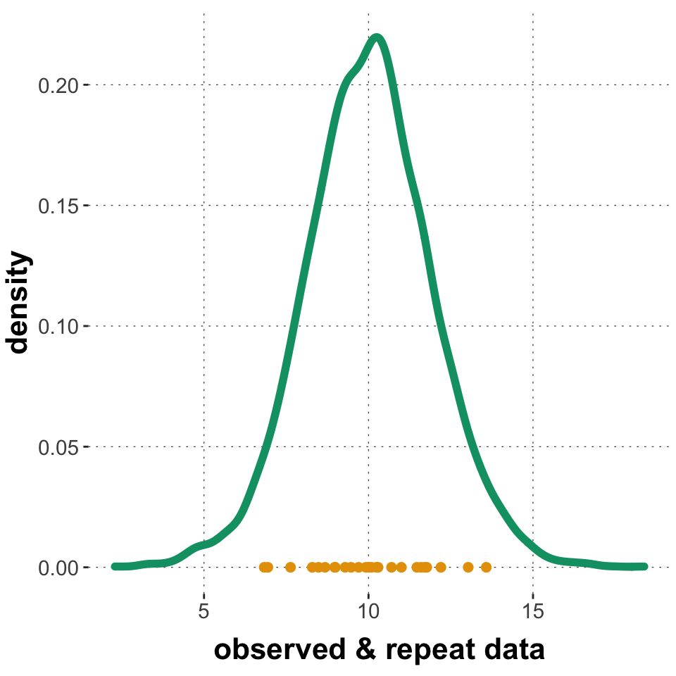

```r
# extract samples from 'stanfit' object in a tidy format
post_samples_1b <- tidybayes::tidy_draws(fit_1b)
# plot posterior predictive samples against the original data
post_samples_1b %>% ggplot(aes(x = yrep)) +
  geom_density(color = project_colors[3], size = 2) +
  geom_point(
    data = tibble(yrep = y, y = 0),
    aes(y = y),
    color = project_colors[1],
    size = 2
  ) +
  xlab("observed & repeat data")
```

We see the distribution of repeat data in green and the original data as orange dots along the $x$-axis. We can interpret this as follows. Given our posterior beliefs (given model and data), be would expect data to be distributed like the green line suggests. The original data (which we used to obtain these beliefs) looks plausibly like samples from this distribution. So, visually, with the implied vagueness, and for this way of comparing $y_\text{obs}$ and $y_\text{rep}$ we may conclude that *this* visual posterior predictive check gives us no ground for alarm.

**Important:** Passing a single (visual) posterior predictive check (PPC) is nothing to write home about. Failing a PPC, on the other hand, is bad *if* the aspect that is not captured by $y_\text{rep}$ but present in $y_\text{obs}$ is theoretically or technically relevant.

## 1.c Obtaining samples from the prior predictive distribution

Next to the posterior predictive distribution, we can also look at a models **prior predictive distribution**. Intuitively, the prior predictive distribution gives us the probability with which we expect, given our *prior* beliefs about the model’s parameters, how likely a future or hypothetical data observation, referred to as $y_\text{pred}$ here (for *predicted data*), is. Formally, the prior predictive distribution is defined as:

$$P(y_\text{pred}) = \int P(\theta) P(y_\text{rep} \mid \theta) \ \text{d} \theta$$

Algorithmically, we can get samples from the prior predictive distribution by obtaining samples from the prior over $\theta$ and then sampling a $y_\text{rep}$ from the likelihood function, given the sampled $\theta$.

Try to implement this in Stan by completing the following model code:

```stan
functions {
  // we need to define our own _rng function because
  // Stan (currently) doesn't allow truncated sampling functions
  real half_cauchy_rng(real spread) {
    return(fabs(cauchy_rng(0, spread)));
  }
}
data {
  int<lower=1> N ;
  vector[N] y ;
}
parameters {
  real mu ;
  real<lower =0> sigma ;
}
model {
  // priors for parameters
  mu ~ normal(0,100);
  sigma ~ cauchy(0,10);
  y ~ normal(mu, sigma);
}
generated quantities {
  // samples from the prior predictive distribution
  real mu_prior;
  real<lower =0> sigma_prior;
  real ypred;
  mu_prior = normal_rng(0,100)
  sigma_prior = half_cauchy_rng(10)
  ypred = normal_rng(mu_prior, sigma_prior)
}
```

Hints: As it stands, this code samples from the posterior. So you need to introduce new variables like `mu_prior` and `sigma_prior` that contain samples from the priors. You do this using notation like `normal_rng()` and `half_cauchy_rng()` inside the `generated quantities` block. In that block, you also declare the variables (including any upper and/or lower bounds). Notice that we had to declare our own function `half_cauchy_rng()` for sampling from a truncated distribution. This easy implementation above works only for truncation at zero, of course.

The solution can be found in file `ADA-W08-Ex1c-single-Gaussian-priorpred.stan`.

If you have written your own Stan code for prior predictive samples, run your file to get samples, like so:

```r
fit_1c = stan(
  file = 'ADA-W08-Ex1c-single-Gaussian-priorpred.stan',
  data = dataList
)
```

Let’s finally make a plot similar to the one in Exercise 1b, to see that the data clearly does not look like representative samples from the prior predictive distribution (which is totally unsurprising, of course!). NB: We restrict the plot of `ypred` to samples of that measure between -50 and 50.

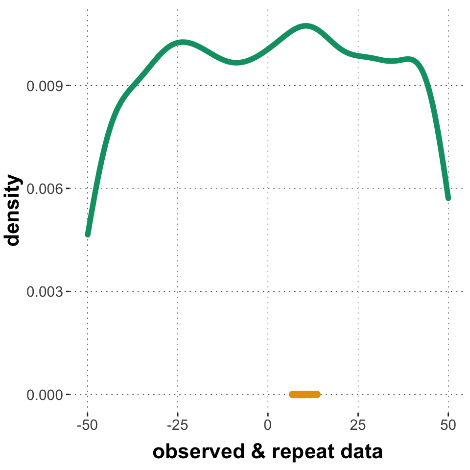

```r
# extract samples from 'stanfit' object in a tidy format
post_samples_1c <- tidybayes::tidy_draws(fit_1c) %>%
  filter(abs(ypred) <= 50)
# plot posterior predictive samples against the original data
post_samples_1c %>% ggplot(aes(x = ypred)) +
  geom_density(color = project_colors[3], size = 2) +
  geom_point(
    data = tibble(ypred = y, y = 0),
    aes(y = y),
    color = project_colors[1],
    size = 2
  ) +
  xlab("observed & repeat data")
```

# Exercise 2 [HOMEWORK]: Outlier-robust inference

Using Stan, we have full control over our model. To see a case where this is useful, let’s consider **robust regression**. Remember that fitting a single Gaussian is like fitting an intercept-only linear regression model. So, what we do here applies to other regression models applied to metric data $y$, too. We are going to see that using a normal likelihood function makes our models very sensitive to outliers. To make them more robust against outliers we can change the likelihood function to using a [Student $t$ distribution](http://bois.caltech.edu/distribution_explorer/continuous/student_t.html), which has thicker tails.

## 2.a Normal likelihood with outliers: what’s the problem? (3 points)

Let’s add two rather extreme outliers to our data of flower heights:

```r
y_prime = c(y, 90,95)
```

We assemble the new data set:

```r
dataList <- list(y = y_prime, N = length(y_prime))
```

And then we use the Stan model from Exercise 1.b which also collects posterior predictives:

```r
# fit the model to the data (we use the same code as for Ex-1b)
fit_2a = stan(
  file = 'ADA-W08-Ex1b-single-Gaussian-prior-postpred.stan',
  data = dataList
)
```

If we inspect the summary statistics of fitted values, we see that, perhaps unsurprisingly but sadly, the inferred mean has changed in response to inclusion of the outliers.

```r
fit_2a
```

```
## Inference for Stan model: ADA-W08-Ex1b-single-Gaussian-prior-postpred.
## 4 chains, each with iter=2000; warmup=1000; thin=1;
## post-warmup draws per chain=1000, total post-warmup draws=4000.
##
##         mean se_mean    sd   2.5%    25%    50%    75%  97.5% n_eff Rhat
## mu     16.24    0.08  4.25   8.04  13.48  16.19  19.07  24.74  3037    1
## sigma  22.34    0.06  3.19  16.98  20.04  21.91  24.25  29.50  2868    1
## yrep   16.55    0.37 22.75 -29.12   1.73  16.81  31.89  60.14  3868    1
## lp__  -96.24    0.02  1.01 -98.94 -96.66 -95.93 -95.52 -95.25  1627    1
##
## Samples were drawn using NUTS(diag_e) at Wed Jun 10 14:17:45 2020.
## For each parameter, n_eff is a crude measure of effective sample size,
## and Rhat is the potential scale reduction factor on split chains (at
## convergence, Rhat=1).
```

That might seem okay, but things are not looking good for this model. We see this if we look at a simple visual posterior predictive check:

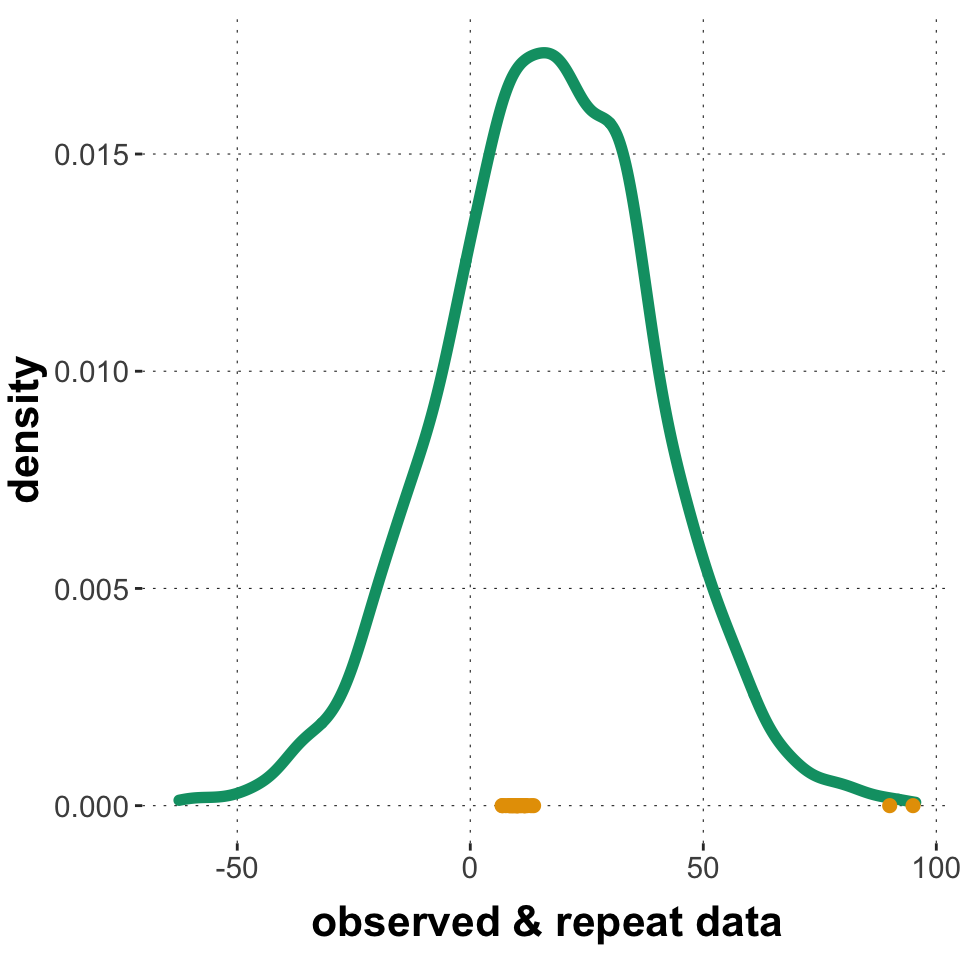

```r
# extract samples from 'stanfit' object in a tidy format
post_samples_2a <- tidybayes::tidy_draws(fit_2a)
# plot posterior predictive samples against the original data
post_samples_2a %>% ggplot(aes(x = yrep)) +
  geom_density(color = project_colors[3], size = 2) +
  geom_point(
    data = tibble(yrep = y_prime, y = 0),
    aes(y = y),
    color = project_colors[1],
    size = 2
  ) +
  xlab("observed & repeat data")
```

What’s the problem? Why does this plot show that the model is not a good model for this data?

```r
# The problem we are facing here, is that the normal distribution as a likelihood takes the mean of the data observations as to represent typical samples. The mean, unfortunately is very prone to outliers which makes the model a non-robust regression model. As a solution one could use the median which is more robust or the student-t distribution whose shape is dependent on parameter nu (degrees of freedom) to allow for thicker tails and thus is less prone to outliers than a normal distribution.
```

## 2.b Using a Student $t$-distribution (7 points)

Complete the Stan code in the code box below, so that it uses a Student $t$ distribution with one degree of freedom. Check out the syntax in the [Stan function reference](https://mc-stan.org/docs/2_18/functions-reference/student-t-distribution.html). Run the model, store the result in a variable called `fit_2b` and show a summary of that `stanfit` object. Look at the mean estimate of the mean and comment on whether it is reasonable or not. (Is it a better estimate than in Ex-2a?) Then plot the posterior predictive alongside the data, reusing the code from Ex-2a. Again comment on whether the result is any better than before.

```stan
data {
  int<lower=1> N ;
  vector[N] y ;
}
parameters {
  real mu ;
  real<lower=0> sigma ;
}
model {
  // priors for parameters
  mu ~ normal(0,100);
  sigma ~ cauchy(0,10);
  y ~ student_t(1,mu,sigma)
}
generated quantities {
  // samples from the posterior predictive distribution
  // notice that, given the code above, mu and sigma are constraint to
  // be samples from the posterior at run time
  real yrep;
  yrep = student_t_rng(1,mu,sigma)
}
```

```r
fit_2b = stan(
  file = 'ADA-W08-Ex2b-student-t-prior-postpred.stan',
  data = dataList
)
```

```r
fit_2b
```

```
## Inference for Stan model: ADA-W08-Ex2b-student-t-prior-postpred.
## 4 chains, each with iter=2000; warmup=1000; thin=1;
## post-warmup draws per chain=1000, total post-warmup draws=4000.
##
##         mean se_mean    sd   2.5%    25%    50%    75%  97.5% n_eff Rhat
## mu      9.97    0.01  0.39   9.19   9.72   9.98  10.21  10.76  2607    1
## sigma   1.38    0.01  0.37   0.81   1.12   1.34   1.59   2.25  3183    1
## yrep   10.38    0.47 29.16  -6.21   8.60   9.92  11.36  27.78  3794    1
## lp__  -43.73    0.03  1.08 -46.58 -44.13 -43.39 -42.99 -42.72  1574    1
##
## Samples were drawn using NUTS(diag_e) at Wed Jun 10 14:19:07 2020.
## For each parameter, n_eff is a crude measure of effective sample size,
## and Rhat is the potential scale reduction factor on split chains (at
## convergence, Rhat=1).
```

```r
# Since we used the more robust student-t distribution for the likelihood of our model now, the mean posterior parameter values now look (definitly more) reasonable again in comparison to the model in 2a.
```

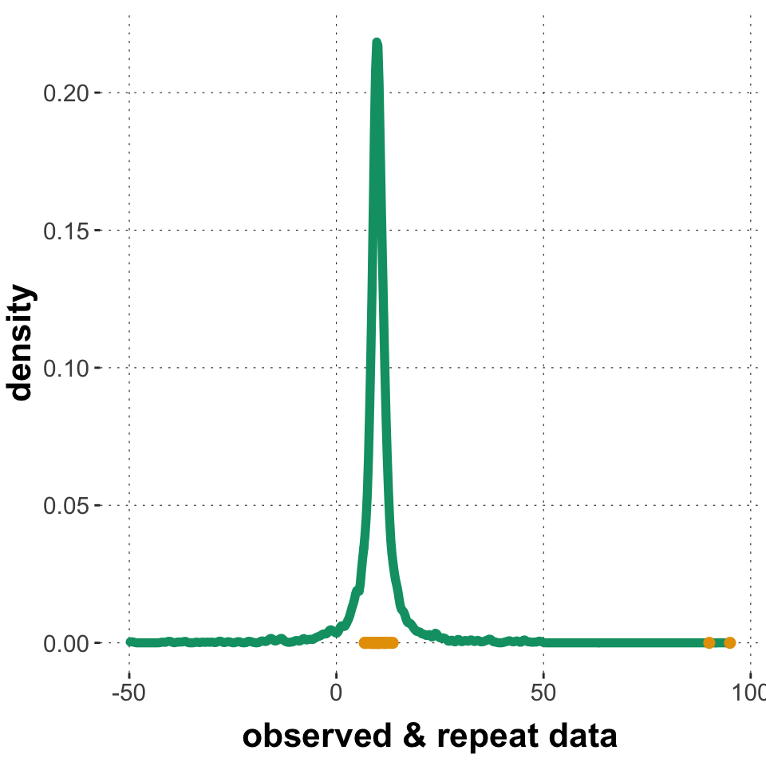

```r
# extract samples from 'stanfit' object in a tidy format
post_samples_2b <- tidybayes::tidy_draws(fit_2b) %>%
  filter(abs(yrep) <= 50)
# plot posterior predictive samples against the original data
post_samples_2b %>% ggplot(aes(x = yrep)) +
  geom_density(color = project_colors[3], size = 2) +
  geom_point(
    data = tibble(yrep = y_prime, y = 0),
    aes(y = y),
    color = project_colors[1],
    size = 2
  ) +
  xlab("observed & repeat data")
```

```r
# The visual posterior predictive check supports our first intuition after seeing the stanfit summary: The model now captures our observed samples much better by assigning a very low posterior probability of being sampled to the outliers with a mroe spikey shape at our more likely data (that we used before adding outliers).
```